# Rasool01519545_CW2

## 2.3 Graph-based analysis ^

In this subtask we analyse the dolphin network, which is tyhe graph of frquuent associations encoded by the adjacency matrix A.

### Data Loading - Adajcency Matrix

Here we load in the data, the adjacency matrix A

```python
# Load the adjacency Matrix
adjacency_matrix = np.load('dolphins_A_62x62(1).npy')
```

Utilise Networkx to visualise the adjacency Matrix

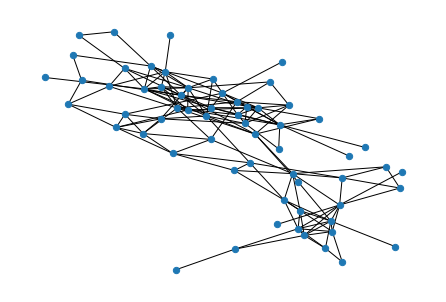

```python
# Visualisse the adjacency Matrix
g = nx.Graph(adjacency_matrix)
# drawing networkx graph
pos = nx.spring_layout(g)
nx.draw(g,pos, node_size=40)
```

### Task 2.3.1 [^]

In this task, we compute the normalised Laplacian of the dolphin network, and its two smallest eigenvalues (and eigenvectors). We then comment on these values to obtain a spectral partition of the graph into two sets of nodes.

We now want to define the symmetric normalized Laplacian of our graph as,

$$ \boldsymbol L = \boldsymbol I - \boldsymbol D^{-1/2}\boldsymbol A \boldsymbol D^{-1/2} $$

where $\boldsymbol D$ is our diagonal matrix of node degrees and $\boldsymbol A$ is our adjacency matrix which we defined earlier.I is the identity matrix

To define our diagonal matrix of degrees $\boldsymbol D$, we must:

1. Sum over the rows of our adjacency matrix
2. Set to a diagonal matrix

Its important to note that we have weighted edges and therefore the degree is simply the sum over the weighted edges.

Here we define a function that computes the nromalised Laplacian.

```python
def laplacian_func(a):
    """
    a: adjacency amtrix

    Returns:
    The computed normalised laplacian of the adjacency matrix

    """
    # define diagonal matrix of node degrees
    weighted_degree = a.sum(axis=1)

    # create diagonal matrix of degree
    D = np.diag(weighted_degree)

    # computing inverse square root vector of degree
    weighted_degree_sqrt = 1.0 / np.sqrt(weighted_degree)

    # set a diagonal matrix of the inverse square root of degree
    D_inv_sqrt = np.diag(weighted_degree_sqrt)

    # define the normalised Laplacian
    L_norm = np.eye(a.shape[0]) - D_inv_sqrt.dot(a.dot(D_inv_sqrt))

    return L_norm
```

```python
# Compute normalised laplacian
L_norm = laplacian_func(adjacency_matrix)
```

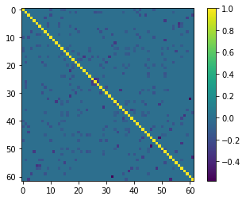

```python
# plot a heatmap of the normalised laplacian
plt.imshow(L_norm)
plt.colorbar();
```

The normalised laplacian has 1's along the diagonal as epxected, everywhere else the values are approximately zero.

We perform Spectral Partition of the grpah to partition the graph into seperate subgraphs.

Lets now examine the spectrum of our Laplacian. We will use the scipy eigsh function to compute the eigenvectors and eigenvalues of our normalised Laplacian.

Note that the eigenvalues and eigenvectors are ordered from smallest to largest.

```python
#return the smallest magnitude eigenvectors and eigenvalues
eigenvals, eigenvecs = linalg.eigsh(L_norm, 2, which="SM", return_eigenvectors=True)
```

```python
# Print first two eigenvalues
print('The first eigenalue is: {}'.format(eigenvals[0]))
print('The second eigenalue is: {}'.format(eigenvals[1]))
```

```
The first eigenalue is: -4.0433117737184027e-17
The second eigenalue is: 0.03952455375743415
```

Discussion:

The first eigenvalue is approximately zero as expected. The second eigenvalue is 0.0395 which will have the biggest contribution, as the cost function requires the first smallest eigenvalue that is not zero to minimise it, therefore it is the second eigenvalue.

We are now interested in a spectral partition. The second eigenvalue corresponds to an eigenvector where the nodes are split into two groups defined by their sign (positive or negative). The resulting eigenvector is also known as the Fiedler vector.

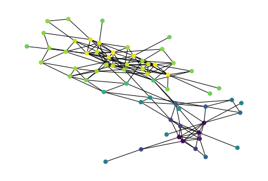

```python
# extract the second eigenvector
second_eigenvector = eigenvecs[:,1]

# draw the network structure coloured by the second eigenvector
nx.draw(g,pos, node_color=second_eigenvector,node_size=40)
```

We now want to binarize our second eigenvector to output a community of 0s and 1s.

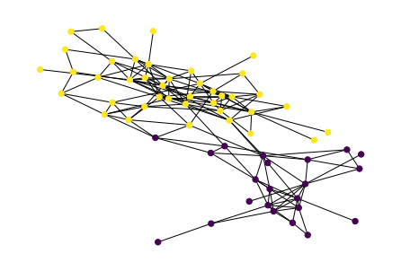

```python
spectral_partition = second_eigenvector
spectral_partition[spectral_partition<0] = 0
spectral_partition[spectral_partition>0] = 1

# draw the spectral partition
nx.draw(g,pos, node_color=spectral_partition, node_size=40)
```

Discussion:

The eigenvalue related to the second eigenvector also called the algebraic connectivity of the graph is directly related to the quality of the bipartition. If the eigenvalue is very small then the cost of splitting the graph into two subgraphs is low, so there exists a good bipartition of the graph. This is true for our case as our second eigenvalue is very small = 0.04, hence our bipartition is good.

### Task 2.3.2 [^]

In this task, we produce three measures of centrality: PageRank, degree centrality and eigenvector centrality. We apply them to the dolphin graph and report the values of the three centralities for all the nodes in the graph. We then study which nodes are highly central according to the three centralities. We use correlation plots to discuss the similarities between the node rankings according to different centrality measures and explain why the centralities may differ.

PageRank:

will assign higher centrality to nodes where many searches will reside with higher probability, where the centrality of the nodes of those incoming edges also plays a role. It is an iterative algorithm and for a given graph with adjacency matrix A, the PageRank centrality of each node is then given by: $c_{PR} = α(AD^{-1})c_{PR} + (1-α)\frac{1}{N}1 $. This is essentially a weighted random walk on the graph. Here $α$ is a probability, called the teleportation parameter and regulates how much the random walk follows the graph or jumps unrestricted. It is customarily set to $α = 0.85$

Degree Centrality:

The importance of a node is defined to be its degree:

$c_d = \frac{d}{2E} = \frac{A1}{2E}$ where A is the adjacency matrix and E is the number of edges.

Eigenvector Centrality: This is looking at spectral graph properties. It stems from the eigendecomposition of the adjacency matrix and assigns higher centrality to those nodes that are themselves connected to other highly central nodes. The centrality of a node i is a function of the centralities of its neighbours and is written as:

$c_e(i) = α∑_jA_{ij}c_e(j)$ which can be reformulated as an eigenvalue/vector problem

$Ac_e = λc_e$ Hence the eigenvector centrality of each node is given by the component of the leading eigenvector of the adjacency matrix.

Degree Centrality

Here we compute the dgeree centrality.

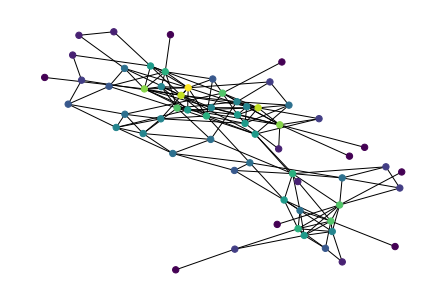

```python
# Compute degree centrality
degree_centrality = adjacency_matrix.sum(axis=1)

# draw the degree distribution
nx.draw(g,pos,node_color=degree_centrality, node_size = 40)
```

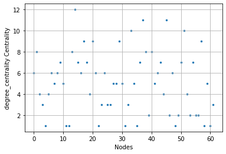

```python
# Below we plot the degree centrality scores in combination with the node
nodes = np.arange(0,62,1)
plt.scatter(nodes, degree_centrality, s = 6)
plt.grid()
plt.xlabel("Nodes")
plt.ylabel("degree_centrality Centrality")
plt.show()
```

Discussion: The figure shows that for degree centrality, a lot of the nodes are concentrated in the lower 2/3 of the graph with only a few nodes such as 14 having high degree centrality.

Eigenvector centrality

Here we compute eigenvector centrality

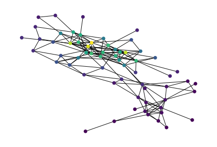

```python
# compute the eigenvector associated with the largest eigenvalue
eigenvalue, eigenvector = linalg.eigsh(adjacency_matrix, 1, which="LM", return_eigenvectors=True) ## <-- SOLUTION

# draw the eigenvector centrality
nx.draw(g,pos,node_color=eigenvector,node_size = 40)
```

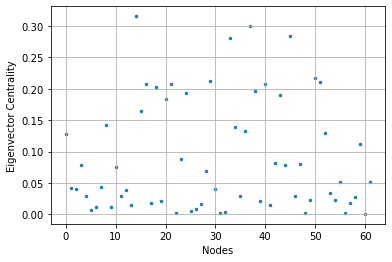

```python
# Below we plot the Eigenvector centrality scores in combination with the node
nodes = np.arange(0,62,1)
plt.scatter(nodes, eigenvector, s = 6)
plt.grid()
plt.xlabel("Nodes")
plt.ylabel("Eigenvector Centrality")
plt.show()
```

Eigenvector centrality shows that most of the nodes have a low centrality score with most clustering in the 0 to 0.05 range. We have a few distinct nodes such as 14.

Pagerank

Here we compute the Pagerank centrality

```python
def page_rank(A, iter):

    """
    a: N x N adjacency matrix
    iter: Number of iterations

    returns:
    Pagerank centrality of the adjacency matrix

    """
    degree = A.sum(axis=1) # compute degree
    # create diagonal matrix of degree
    D = np.diag(degree) # diagonalise
    cpr = 1
    weighted_degree = A.sum(axis=1)  # compute weighted dehree
    N = 62
    pr = np.ones(N).reshape(N, 1) * 1./N # initialise to correct shape
    I = np.identity(N)

    inv_D =np.diag(1/ weighted_degree) # inverse of weighted degree

    for i in range(iter):
        pr = 0.85 * A.dot(inv_D.dot(pr)) + (1-0.85)*(1/N)*I # compute pagerank iteratively
    pr = pr.sum(axis = 1)

    return pr
```

```python
# Here we run the algorithm for pagerank
Pagerank_score = page_rank(adjacency_matrix, iter = 100)
```

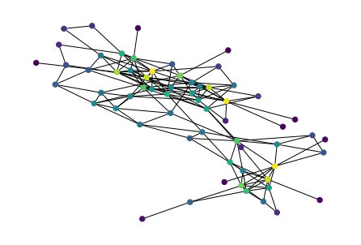

```python
# Plot the PageRank centrality
nx.draw(g,pos, node_color = Pagerank_score,node_size = 40 )
```

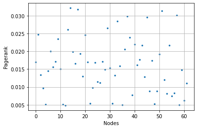

```python
# Below we plot the page rank scores in combination with the node
nodes = np.arange(0,62,1)
plt.scatter(nodes, Pagerank_score, s = 6)
plt.grid()
plt.xlabel("Nodes")
plt.ylabel("Pagerank")
plt.show()
```

Pagerank centrality shows an almost even distribution of nodes around the figure, different from eigenvector centrality which had most values concentrated near the bottom.

Below shows the implementation of a correlation matrix between the different measures of centrality

```python
# Correlation Martrix construction
data = {'Pagerank': list(Pagerank_score),
        'Eigenvector Centrality': list(np.ravel(eigenvector)),
        'Degree Centrality': list(degree_centrality)
        }



centrality_frame = pd.DataFrame(data, columns=['Pagerank','Eigenvector Centrality','Degree Centrality'])
corrMatrix = centrality_frame.corr()
print(corrMatrix)
```

```
                        Pagerank  Eigenvector Centrality  Degree Centrality
Pagerank                1.000000                0.609418           0.983095
Eigenvector Centrality  0.609418                1.000000           0.719648
Degree Centrality       0.983095                0.719648           1.000000
```

We also look at the msot central dolphins by choosing the top five dolphins from each centrality measurement.

```python
# Below we first define an orignal indicies measurement for each centralities
pg_nodes_ordered = list(np.flip(np.argsort(Pagerank_score)))
deg_nodes_ordered = list(np.flip(np.argsort(degree_centrality)))
eigen_nodes_ordered = list(np.flip(np.argsort(np.ravel(eigenvector))))

# Define the names in rank order
dolphin_page_rank = dolphin_names.iloc[pg_nodes_ordered ].to_numpy()
dolphin_deg_rank = dolphin_names.iloc[deg_nodes_ordered].to_numpy()
dolphin_eigen_rank = dolphin_names.iloc[eigen_nodes_ordered].to_numpy()

ranking = {'Pagerank': list(np.ravel(dolphin_page_rank)),
        'Eigenvector Centrality': list(np.ravel(dolphin_eigen_rank )),
        'Degree Centrality': list(np.ravel(dolphin_deg_rank))
        }
# Ordered ranking of names from highest centrality to lowest
merge_ranking = pd.DataFrame(ranking, columns=['Pagerank','Eigenvector Centrality','Degree Centrality'])
display(merge_ranking)
```

|  | Pagerank | Eigenvector Centrality | Degree Centrality |
| --- | --- | --- | --- |
| 0 | 14 | 14 | 14 |
| 1 | Grin | Grin | Grin |
| 2 | 17 | 37 | 45 |
| 3 | Jet | SN4 | Topless |
| 4 | 51 | 45 | 37 |
| ... | ... | ... | ... |
| 119 | Whitetip | Quasi | SMN5 |
| 120 | 35 | 48 | 22 |
| 121 | SMN5 | TR82 | MN23 |
| 122 | 12 | 60 | 48 |
| 123 | Fork | Zig | TR82 |

124 rows × 3 columns

Discussion of results:

We first look at the node rankings according to different centrality measures. Which is the panda's frame above. What we can see from the correlation matrix between the centralities methods is that Pagerank and degree centralities are highly correlated, whereas Eigenvector centrality is not as correlated with Pagerank.

The centrality measures might differ because they aim to capture different behaviours to define the centralities.

I then identified the most central dolphins, in the pandas from above which shows that all the centralities methods have the same most central dolphin, Grin, but after that, it changes to different dolphins.

Eigenvector centrality is useful because it indicates direct influence and also infleuce ovver nodes more than one node away.

Whereas Pagerank centrality helps uncover influential or important nodes whose reach extends beyond their direct conectiosn especially where link direciton is importnat.

Therefore pagerank is a very specific case of Eigenvector centrality where direcion is important. Therefore there is a mediunm correlation between the two methods.

Pagerank has a higher correlation with degree centrality because for an undirected graph Pagerank is equivalent to the degree.

Looking at the Sociogram in the paper on the dolphins, we can that the Web has the greatest degree of centrality. However, this is not what is seen in my results as I obtain that Grin has the highest degree of centrality.

# Task 3: Mastery Component ^

## 3.1 Non-Negative Matrix Factorization (NMF) for dimensionality reduction ^

In this task we consider the same N = 1000 images from the Fashion-MNIST dataset used in Task 2.1. In this task we perform Non-Negative Matrix Factorization (NMF) for dimensionality reduction.

### Task 3.1.1 [^]

In this task we perform dimensionality reduction using NMF. We find the optimal NMF using 500 iterations and m = 10 dimensions onto which to project the data. We then plot the convergence of the algorithm as a function of the iterations. Now we will look at non-negative matrix factorisation. NMF is a matrix factorization method where we constrain the matrices to be nonnegative. PCA previously produced factors that could be both positive and negative.

NMF factors our n-by-m feature matrix $\mathbf X$ into nonnegative factors $\mathbf W$ (n-by-k) and $\mathbf H$ (k-by-m). The factorization is not exact. $\mathbf W\mathbf H$ is a lower-rank approximation to $\mathbf A$. The factors $\mathbf W$ and $\mathbf H$ minimize the root mean square residual D between $\mathbf X$and $\mathbf W\mathbf H$.

We require the input matrix to be non-negative. Therefore, we must normalise between 0 and 1 instead of standard normalise which we used for PCA and SVD.

Here we will use Lee and Seung's multiplicative update rule.

$ \mathbf{H}_{[i,j]}^{n+1}\leftarrow \mathbf{H}_{[i,j]}^{n} \frac{(( \mathbf{W}^n)^T \mathbf{X})_{[i,j]}}{((\mathbf{W}^n)^T \mathbf{W}^n \mathbf{H}^n)_{[i,j]}} $

and

$ \mathbf{W}_{[i,j]}^{n+1}\leftarrow \mathbf{W}_{[i,j]}^{n} \frac{(\mathbf{X}(\mathbf{H}^{n+1})^T)_{[i,j]}}{(\mathbf{W}^n \mathbf{H}^{n+1} (\mathbf{H}^{n+1})^T)_{[i,j]}} $

until $\mathbf{W}$ and $\mathbf{H}$ are stable.

We need to get the data and reshape it to the correct dimensions.

```python
# Create subset of the data
(x_train_NMF, y_train_NMF) = x_train_nn[:1000], y_train_nn[:1000]
# reshape data to correct dimensions
x_train_NMF = x_train_NMF.reshape(-1,28*28)
```

```python
# We define a normalise function for NMF
# normalise min max to 0-1
def normalize_nmf(X):
    """
    X: N x k matrix

    return:
    N x K matrix that has been normlaised based

    """
    e = 1e-12 # introduce shift to prevent NANs
    X_norm = (X- np.min(X+ e)) / (np.max(X) - np.min(X+ e))
    return X_norm


# The use NMF normlalising
x_train_NMF = normalize_nmf(x_train_NMF)
```

define intialise parameters function for NMF

```python
def initialise_NMF(X, k):
    """
    X: Matrix of size N x k
    k: integer specifying number of dimensions to project onto.

    return:
    W: array of shape N x k
    H: array of shape k x k
    """
    # setting the random seed (just so everyone gets the same results...)
    np.random.seed(42)

    # m x n components matrix, usually interpreted as the basis set
    W = np.random.rand(X.shape[0], k)

    # n x n matrix interpreted as the coefficients
    H = np.random.rand(k,X.shape[1])

    return H,W
```

We define a cost function

```python
def cost(X,W,H):
    """
    X : Matrix of size N x k
    W: array of shape N x k
    H: array of shape k x k

    return:
    chi2: Integer representing chi-squared

    """

    # compute the difference between X and the dot product of W and H
    diff = X - np.dot(W, H)

    chi2 = ((X*diff) * diff).sum() / (X.shape[0]*X.shape[1])

    return chi2
```

```python
def NMF_func(X,k,iter):
    """
    X : Matrix of size N x k
    k: integer specifying number of dimensions to project onto.
    iter: integer representing max number of iterations

    return:
    array of values

    This function returns the computed chi-squared values for the NMF
    dimensionality reduction

    """
    H , W = initialise_NMF(X, k)


    # empty list for chi2
    chi2 = []

    # loop over the n iterations
    for i in range(iter):

        # compute the update on H
        H = H * ((W.T.dot(X)) / W.T.dot(W.dot(H)))


        # compute the update on W
        W = W * ((X.dot(H.T)) / (W.dot(H.dot(H.T))))

        # compute the chi2 and append to list
        chi2.append(cost(X,W,H))
    return chi2, W , H
```

We now run the function defined above as required.

```python
# Run the NMF algorithm
ch2, W, H = NMF_func(x_train_NMF,k = 10,iter = 500)
```

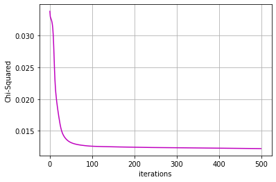

```python
plt.plot(ch2, color = 'm')
plt.xlabel("iterations")
plt.ylabel("Chi-Squared")
plt.grid()
```

### Task 3.1.2 [^]

In this task we write the formula to express the image data as a linear combination of non-negative components and visualize the m = 10 components ussing imshow. These are the non-negative cequivalents of the principal components from PCA.

The linear combination of non-negative components is repsented by X$_{approx}$= WH, where H contains the non-negative equivalnet of the principal components and the matrix W contains the non-negative coefficients expresssing the data in the baiss of vectors in H.

Below I show the code for the approximations of the images of the cloths using PCA and and NMF for m = 10 principal components.

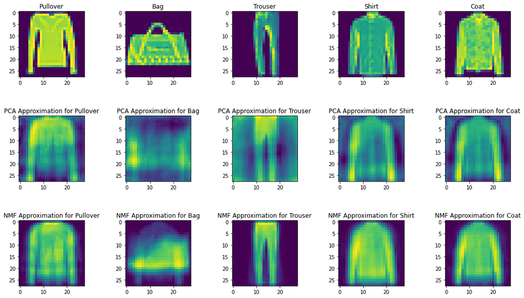

```python
# Code to plot the approximations of the dimensionality reduction methods

n_rows, n_cols = 3, 5
np.random.seed(1)
random_inx = np.random.choice(1000, 5, replace=False)
fig, axes = plt.subplots(n_rows, n_cols, figsize=(18, 10))
fig.subplots_adjust(hspace=0.6, wspace=0.3)

random_inx = np.hstack((random_inx,) * 3)

for n, i in enumerate(random_inx):
    row = n // n_cols
    col = n % n_cols
    if row == 1:
        axes[row, col].imshow((X_pca_25[i,:10]@eigenvectors_25.T[:10,:]).reshape(-1,28)) # plot approximation for PCA
        axes[row,col].set_title('PCA Approximation for '+str(classes[np.argmax(y_train_nn[i])]))
    elif row == 0:
        axes[row, col].imshow(x_train_nn[i]) # plot original image
        axes[row,col].set_title(str(classes[np.argmax(y_train_nn[i])]))
    elif row == 2:
        axes[row, col].imshow((W[i,:10]@H[:10,:]).reshape(-1,28)) # plot approximation for NMF
        axes[row,col].set_title('NMF Approximation for '+str(classes[np.argmax(y_train_nn[i])]))

plt.show()
```

The images show the approximations of the actual images using the dimensionality reduction algorithms for NMF and PCA for the first m = 10 principal components.

Between PCA and NMF:

We see that the NMF performs significantly better in dimensionality reduction than PCA as its ability to retain a better resolution image of the individual cloths. Both algorithms do not perform well on the bags.

They differ because NMF only uses positive eigenvectors which prevents negative values.

There is a difference between the images here and the feature maps obtained in 1.2.4. Firstly the feature maps are one image that is broken down into more abstract features as we increase the number of Conv layers whereas here we are looking at the approximations due after dimensionality reduction. The features are not abstract here.

Below we visualise the eigenvectors for NMF (H)

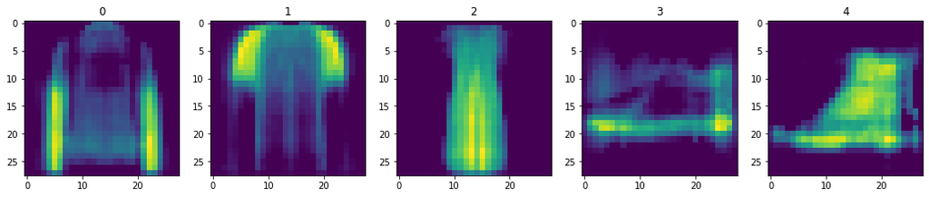

```python
# Visulasing the eigenvectors for NMF (H)
nrow = 1; ncol = 5;
fig, axes = plt.subplots(nrow, ncol, figsize=(18, 10))
fig.subplots_adjust(hspace=0.3, wspace=0.2)
for i,ax in enumerate(axes.reshape(-1)):
    ax.imshow(H[i,:].reshape([28,28]))
    ax.set_title(str(i))
```

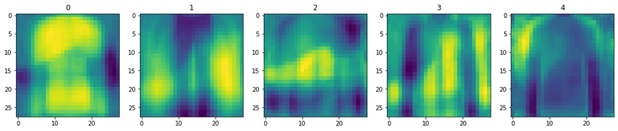

```python
# Visualising the eigenvectors for PCA
nrow = 1; ncol = 5;
fig, axes = plt.subplots(nrow, ncol, figsize=(18, 10))
fig.subplots_adjust(hspace=0.3, wspace=0.2)
for i,ax in enumerate(axes.reshape(-1)):
    ax.imshow(eigenvectors_25[:,i].reshape(-1,28))
    ax.set_title(str(i))
plt.show()
```

Visualising the eigenvectors for PCA and NMF we can see that the NMF performs significantly better as we can identify the items quite clearly whereas for PCA the figures are beginning to blur and it has become difficult to make out a difference. There is less contrast for PCA. One reason is becasue PCA may ahve negative pixel values which may contribute to the image being less sharp.

In Conv we are trying to see the abstract features whereas in PCA NMF we are not doing this.

The PCA images are closer in similarity to the deeper layers in the Conv model (visually) whereas NMF looks similar to the shallower levels in the Conv model. One of the reasons why this is the case could be because filters are used in the Conv model which essentially reduces the dimensions of the image (like the PCA and NMF models)

## 3.2 Community detection ^

### 3.2.1 Modularity maximisation with Louvain algorithm

In this task we utilise the Louvain algorithm to maximise modularity in the NetworkX package, find the optimal community structure for the dolphin graph.

```python
import networkx.algorithms.community as nx_comm
```

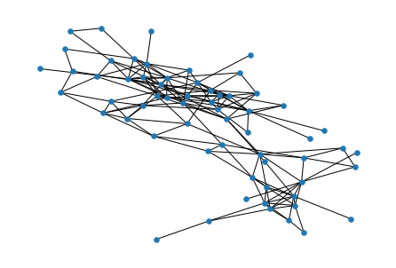

```python
# PLot our orignal network
adjacency_matrix

g = nx.Graph(adjacency_matrix)
# drawing networkx graph
nx.draw(g,pos, node_size=30)
```

```python
# Call the louvain function
partition = nx_comm.louvain_communities(g, seed=123)
```

Define a function that allows us to colour nodes based on their cluster

```python
def parts_func(partition):
    """
    partition: A list with setss of numbers which shouws their clusters
    return: A colour assignment for each node

    """
    indexes = np.zeros((62,))
    list_parts = []
    for i in range(len(partition)):
        for j in partition[i]:
            indexes[j] = i
    return indexes
```

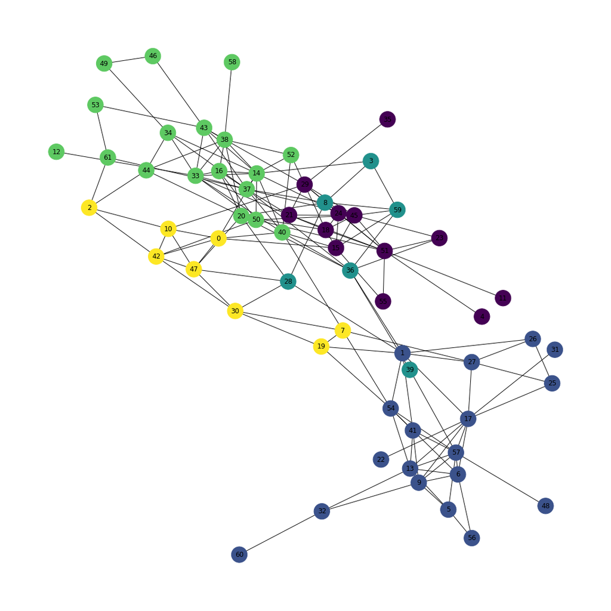

```python
# Call the parts_func to obtain colour assignment and draw the network
plt.figure(figsize = (15,15))
indexes = parts_func(partition)
nx.draw(g,pos,node_color=indexes, node_size =800,with_labels=True)
```

Discussion of results:

The top 3 ranked dolphins for Pagerank are: Grin (index = 14), Jet(index = 17), Trigger (index = 51). If we look at the Louvain figure above we can see that the top three ranked dolphins are in separate clusters. They are also at the centre of their respective clusters which shows that the results agree with the measurement of Pagerank centrality. This is visualised in the graph above.

This is also simmilar for the eigenvector centrality and degre centrality. Where the dolphins with the highest centrality are located at the centre of their clusters.

### 3.2.2 Compare Clusterings

In this task, we use Adjusted Rand Index (ARI) function from sklearn to quantify how similar the graph-based node clustering obtained in 3.2.1 is to the feature-based node clsuterings obtained in 2.2.

```python
from sklearn import metrics
ARI = []
for i in range(62):
    id = metrics.adjusted_rand_score(indexes , hierarchical_clusters[i,:])
    ARI.append(id)
```

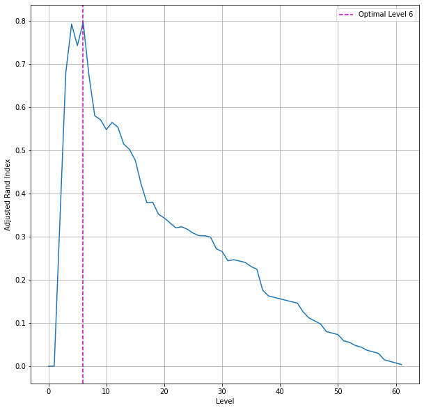

```python
# Plot the ARI values for each level of the heirarchical cluster
plt.figure(figsize = (10,10))
plt.plot(ARI)
plt.grid()
plt.xlabel("Level")
plt.ylabel("Adjusted Rand Index")
plt.axvline(np.argmax(ARI), ls = '--', color = 'm', label = 'Optimal Level '+str(np.argmax(ARI)))
plt.legend()
plt.show()
```

Homophily is a phenomenon where users with similar contexts have the nature of connecting constantly. The principle of the idea is that an individual's network tends to be more homogeneous than heterogeneous, such that communication between similar individuals occurs more frequently than with dissimilar individuals.

This essentially means that there are more connections within a cluster. This is represented by the Louvain algorithm and the subsequent network plotted above. Louvain builds by clustering nodes based on connections, and samples that are more connected will be clustered together, which shows homophily.

The fact that grouping individuals with their closeness as part of hierarchical clustering increases the communications between them shows the principle of homophily.